# Simulated RIT Equating

Chris Haid

April 7, 2014

First, let’s load the packages we’ll sue

```r
require(rjags)
```

```r
require(Rgraphviz)
```

Create some simulated data:

```r
set.seed(432104)
```

# Simulated RIT Equating Example

## First pass at a model

OK. So let’s define a simple model is the basis for our simulated data and our probabilistic model of inference. First we’ll assume that there is in fact a latent ability attribute, $\theta_i$, for each student $i \in {1,\dots,.n}$ in our sample. Further, we’ll assume that this latent trait is accurately measured by an *unobserved* RIT score, which we’ll denote $r_{i}$. In other words, RIT scores are a direct measure of $\theta_i$. Luckingly for us, students take a test that gives us an estimate of RIT scores, the MAP. So we assume that the observed RIT, $\hat{r}$ is a realization from a distribution centered on $r$ Finally, we assuem that all other academic measures (interim assessments, Kahn objectives, individual test items, even Do Nows/Exit Tickets). So we have observed realization of a RIT score for a student as well as all the other academic indicators. All other RVs and parameters need to be estimated. And our goal here is to make inferences about $r_i$ given our observation of other acadmeic indicators.

Here’s a graphical representation of our probaility model:

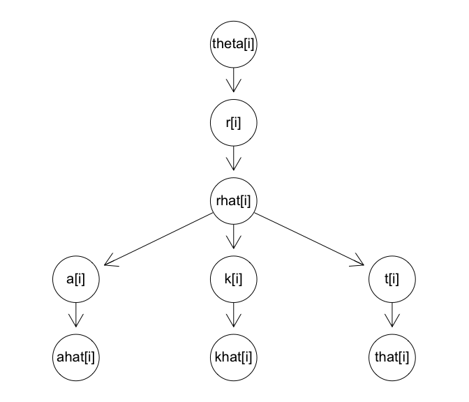

```r
rit.graph <- new("graphNEL",
                 nodes=c("theta[i]",
                         "r[i]",
                         "rhat[i]",
                         "a[i]",
                         "k[i]",
                         "t[i]",
                         "ahat[i]",
                         "khat[i]",
                         "that[i]"
                         ),
                 edgemode="directed")

rit.graph <- addEdge("theta[i]", "r[i]", rit.graph, 1)
rit.graph <- addEdge("r[i]", "rhat[i]" , rit.graph, 1)
rit.graph <- addEdge("rhat[i]", "a[i]" , rit.graph, 1)
rit.graph <- addEdge("rhat[i]", "k[i]" , rit.graph, 1)
rit.graph <- addEdge("rhat[i]", "t[i]" , rit.graph, 1)
rit.graph <- addEdge("a[i]", "ahat[i]" , rit.graph, 1)
rit.graph <- addEdge("k[i]", "khat[i]" , rit.graph, 1)
rit.graph <- addEdge("t[i]", "that[i]" , rit.graph, 1)

plot(rit.graph)
```

Now, let’s simulate some data based on this basic probability model. The $\theta_i$’s need a prior and I’ll use the school level norms (because I’m on a plane and don’t have the student level norms with me; we can change these later) for fall 5th grade math. Thinking about this, we can collapse the $\theta_i$s and $r_i$, sunce we are assuming theta exists on the the RIT scale. I’ll use $\theta_i$ to denote the RIT-scaled laten variable.

```r
set.seed(432104)

n <- 90 # number of students

theta<-rnorm(n = n, mean = 211.39, sd =5.83)
```

The $\theta_i$s are then noisily measured by the MAP test. I’ll assume a standard deviation of about 3, but that is completely arbitrary.

```r
rhat<-rnorm(n, theta, sd=rep(3, times=n))

head(rhat)
```

```
## [1] 211.9 226.3 195.8 217.3 201.2 227.7
```

Ok. let’s make some assumptions about how $\hat{r}$ is related to each of the three realizations of our academic indicators. Let’s start with some arbitrary assessment that is graded on a zero to one scale (or zero to 100%) a realization of which is denoted $\hat{a}_i$. We’ll keep it simple and assume that the $\hat{r}_i$ are linear predictors of $z.a_{i}$ in the inverse-logistic function. That is,

$\begin{aligned} z.a_{i} & = \alpha + \beta \cdot \hat{r}_i \\ \hat{a}_{i} & = \frac{1}{1+\exp^{-z.a{i}}} \end{aligned}$

```r
alpha<- -1
beta<-.01
z.a<- alpha +  beta*rhat
ahat<-1/(1+exp(-z.a))
head(z.a)
```

```
## [1] 1.119 1.263 0.958 1.173 1.012 1.277
```

```r
head(ahat)
```

```
## [1] 0.7538 0.7796 0.7227 0.7637 0.7333 0.7820
```

Let’s pretend, for now, that this the only non-MAP assessment that we have. All we observed are the $\hat{a}_i$